# Project Python Foundations: FoodHub Data Analysis

### Context

The number of restaurants in New York is increasing day by day. Lots of students and busy professionals rely on those restaurants due to their hectic lifestyles. Online food delivery service is a great option for them. It provides them with good food from their favorite restaurants. A food aggregator company FoodHub offers access to multiple restaurants through a single smartphone app.

The app allows the restaurants to receive a direct online order from a customer. The app assigns a delivery person from the company to pick up the order after it is confirmed by the restaurant. The delivery person then uses the map to reach the restaurant and waits for the food package. Once the food package is handed over to the delivery person, he/she confirms the pick-up in the app and travels to the customer's location to deliver the food. The delivery person confirms the drop-off in the app after delivering the food package to the customer. The customer can rate the order in the app. The food aggregator earns money by collecting a fixed margin of the delivery order from the restaurants.

### Objective

The food aggregator company has stored the data of the different orders made by the registered customers in their online portal. They want to analyze the data to get a fair idea about the demand of different restaurants which will help them in enhancing their customer experience. Suppose you are hired as a Data Scientist in this company and the Data Science team has shared some of the key questions that need to be answered. Perform the data analysis to find answers to these questions that will help the company to improve the business.

### Data Description

The data contains the different data related to a food order. The detailed data dictionary is given below.

### Data Dictionary

- order_id: Unique ID of the order
- customer_id: ID of the customer who ordered the food
- restaurant_name: Name of the restaurant
- cuisine_type: Cuisine ordered by the customer
- cost_of_the_order: Cost of the order
- day_of_the_week: Indicates whether the order is placed on a weekday or weekend (The weekday is from Monday to Friday and the weekend is Saturday and Sunday)
- rating: Rating given by the customer out of 5
- food_preparation_time: Time (in minutes) taken by the restaurant to prepare the food. This is calculated by taking the difference between the timestamps of the restaurant's order confirmation and the delivery person's pick-up confirmation.
- delivery_time: Time (in minutes) taken by the delivery person to deliver the food package. This is calculated by taking the difference between the timestamps of the delivery person's pick-up confirmation and drop-off information

### Let us start by importing the required libraries

```python
# Installing the libraries with the specified version.
!pip install numpy==1.25.2 pandas==1.5.3 matplotlib==3.7.1 seaborn==0.13.1 -q --user
```

**Note**: *After running the above cell, kindly restart the notebook kernel and run all cells sequentially from the start again.*

```python
# import libraries for data manipulation
import numpy as np
import pandas as pd

# import libraries for data visualization
import matplotlib.pyplot as plt
import seaborn as sns

# Set the format of floating point numbers to 2 decimal places
pd.options.display.float_format = '{:.2f}'.format
```

### Understanding the structure of the data

```python
# uncomment and run the following lines for Google Colab
from google.colab import drive
drive.mount('/content/drive')
```

```python
# Write your code here to read the data
data = pd.read_csv('/content/drive/MyDrive/Colab Notebooks/Project 1/foodhub_order.csv')
```

```python
# Write your code here to view the first 5 rows
data.head()
```

|  | order_id | customer_id | restaurant_name | cuisine_type | cost_of_the_order | day_of_the_week | rating | food_preparation_time | delivery_time |
| --- | --- | --- | --- | --- | --- | --- | --- | --- | --- |
| 0 | 1477147 | 337525 | Hangawi | Korean | 30.75 | Weekend | Not given | 25 | 20 |
| 1 | 1477685 | 358141 | Blue Ribbon Sushi Izakaya | Japanese | 12.08 | Weekend | Not given | 25 | 23 |
| 2 | 1477070 | 66393 | Cafe Habana | Mexican | 12.23 | Weekday | 5 | 23 | 28 |
| 3 | 1477334 | 106968 | Blue Ribbon Fried Chicken | American | 29.20 | Weekend | 3 | 25 | 15 |
| 4 | 1478249 | 76942 | Dirty Bird to Go | American | 11.59 | Weekday | 4 | 25 | 24 |

Data set has been loaded properly

### **Question 1:** How many rows and columns are present in the data? [0.5 mark]

```python
# Write your code here
data.shape
```

```
(1898, 9)
```

#### **Observations**:

The dataset has 1898 rows with 9 columns

### **Question 2:** What are the datatypes of the different columns in the dataset? (The info() function can be used) [0.5 mark]

```python
# Write your code here
data.info()
```

```
<class 'pandas.core.frame.DataFrame'>
RangeIndex: 1898 entries, 0 to 1897
Data columns (total 9 columns):
 #   Column                 Non-Null Count  Dtype
---  ------                 --------------  -----
 0   order_id               1898 non-null   int64
 1   customer_id            1898 non-null   int64
 2   restaurant_name        1898 non-null   object
 3   cuisine_type           1898 non-null   object
 4   cost_of_the_order      1898 non-null   float64
 5   day_of_the_week        1898 non-null   object
 6   rating                 1898 non-null   object
 7   food_preparation_time  1898 non-null   int64
 8   delivery_time          1898 non-null   int64
dtypes: float64(1), int64(4), object(4)
memory usage: 133.6+ KB
```

#### **Observations**:

- There are 4 object data type columns
- There are 5 numeric data type columns - 4 columns as integers and 1 column as float
- Data type for the rating column has been identified as object, although it should ideally be integer as ratings are given in numbers. This could be due to orders that may not have been rated

### **Question 3:** Are there any missing values in the data? If yes, treat them using an appropriate method. [1 mark]

```python
# Write your code here
data.isnull().sum()
```

|  | 0 |
| --- | --- |
| order_id | 0 |
| customer_id | 0 |
| restaurant_name | 0 |
| cuisine_type | 0 |
| cost_of_the_order | 0 |
| day_of_the_week | 0 |
| rating | 0 |
| food_preparation_time | 0 |
| delivery_time | 0 |

**dtype:** int64

```python
# Check unique values for restaurant name
data.restaurant_name.unique()
```

```
array(['Hangawi', 'Blue Ribbon Sushi Izakaya', 'Cafe Habana',
       'Blue Ribbon Fried Chicken', 'Dirty Bird to Go',
       'Tamarind TriBeCa', 'The Meatball Shop', 'Barbounia',
       'Anjappar Chettinad', 'Bukhara Grill',
       'Big Wong Restaurant \x8c_¤¾Ñ¼', 'Empanada Mama (closed)', 'Pylos',
       "Lucky's Famous Burgers", 'Shake Shack', 'Sushi of Gari',
       'RedFarm Hudson', 'Blue Ribbon Sushi',
       'Five Guys Burgers and Fries', 'Tortaria', 'Cafe Mogador',
       'Otto Enoteca Pizzeria', 'Vezzo Thin Crust Pizza',
       'Sushi of Gari 46', 'The Kati Roll Company', 'Klong',
       '5 Napkin Burger', 'TAO', 'Parm', 'Sushi Samba',
       'Haru Gramercy Park', 'Chipotle Mexican Grill $1.99 Delivery',
       'RedFarm Broadway', 'Cafeteria', 'DuMont Burger',
       "Sarabeth's East", 'Hill Country Fried Chicken', 'Bistango',
       "Jack's Wife Freda", "Mamoun's Falafel", 'Prosperity Dumpling',
       'Blue Ribbon Sushi Bar & Grill', 'Westville Hudson',
       'Blue Ribbon Brooklyn', 'Nobu Next Door', 'Osteria Morini',
       'Haandi', 'Benihana', 'Han Dynasty', 'Chote Nawab',
       'Mission Cantina', "Xi'an Famous Foods", 'Rubirosa',
       "Joe's Shanghai \x8e_À\x8eü£¾÷´", 'Bareburger', 'The Odeon',
       'Pongsri Thai', 'Yama Japanese Restaurant', 'Momoya',
       'Balthazar Boulangerie', 'CafÌ© China', 'Boqueria',
       'Song Thai Restaurant & Bar', 'Five Leaves',
       'Pinto Nouveau Thai Bistro', "Amy Ruth's", 'Pepe Giallo',
       'indikitch', 'Yama 49', 'Piccolo Angolo', 'Pepe Rosso To Go',
       "L'Express", 'Amma', 'Delicatessen', "S'MAC",
       "Vanessa's Dumplings", 'Bhatti Indian Grill', 'Taro Sushi',
       'Donburi-ya', 'Hatsuhana', 'Samurai Mama', 'Waverly Diner',
       'Tarallucci e Vino Restaurant', "P.J. Clarke's",
       'Lantern Thai Kitchen', 'ilili Restaurant', 'The Smile',
       "Vanessa's Dumpling House", "Bubby's ", 'Woorijip',
       'Dirty Bird To Go (archived)', 'Haveli Indian Restaurant',
       'Dos Caminos', 'da Umberto', 'Sushi of Gari Tribeca',
       'Burger Joint', 'Room Service', "Sarabeth's Restaurant",
       'Xe May Sandwich Shop', 'Hibino', 'Mira Sushi', 'Melt Shop',
       'J. G. Melon', 'Hummus Place', 'Saravanaa Bhavan',
       'Friend of a Farmer', 'The Loop', 'Balade', 'Posto',
       'Terakawa Ramen', 'Kambi Ramen House', 'Wo Hop Restaurant',
       'Spice Thai', "Dickson's Farmstand Meats",
       'UVA Wine Bar & Restaurant', 'Serafina Fabulous Pizza',
       'Gaia Italian Cafe', 'Chola Eclectic Indian Cuisine',
       'Hot Kitchen', 'Junoon', 'Ravagh Persian Grill', 'Rohm Thai',
       'Dig Inn Seasonal Market', 'Olea', 'Cho Dang Gol',
       'El Parador Cafe', 'Socarrat Paella Bar',
       "Don's Bogam BBQ & Wine Bar", 'Alidoro', "Tony's Di Napoli",
       'Cipriani Le Specialita', 'Sushi Choshi', 'Kanoyama', 'V-Nam Cafe',
       'Zero Otto Nove', 'Dos Caminos Soho', 'Go! Go! Curry!',
       'La Follia', 'Izakaya Ten', '12 Chairs', 'Philippe Chow',
       'The MasalaWala', 'brgr', "Carmine's", 'Asuka Sushi', 'Aurora',
       "Sarabeth's", 'Crema Restaurante', "Big Daddy's",
       'Moonstruck on Second', 'Cafe de La Esquina', 'Olive Garden',
       '67 Burger', 'Tres Carnes', "Schnipper's Quality Kitchen",
       'Nha Trang One', 'Market Table', 'Galli Restaurant',
       'Hampton Chutney Co.', 'Byblos Restaurant',
       'Grand Sichuan International', 'Le Grainne Cafe', 'Il Bambino',
       'Kori Restaurant and Bar', 'DespaÌ±a', 'Lamarca Pasta',
       'Lucky Strike', "Paul & Jimmy's", 'Hunan Manor', "Coppola's East",
       'Emporio', 'Wa Jeal', 'Le Zie 2000 Trattoria', 'Rye House',
       "Hiroko's Place", 'Frank Restaurant', "Sarabeth's West",
       "'wichcraft"], dtype=object)
```

```python
# Check unqiue values for cuisine type
data.cuisine_type.unique()
```

```
array(['Korean', 'Japanese', 'Mexican', 'American', 'Indian', 'Italian',
       'Mediterranean', 'Chinese', 'Middle Eastern', 'Thai', 'Southern',
       'French', 'Spanish', 'Vietnamese'], dtype=object)
```

```python
# Check unique values for day of the week
data.day_of_the_week.unique()
```

```
array(['Weekend', 'Weekday'], dtype=object)
```

```python
# Check unique values for rating
data.rating.unique()
```

```
array(['Not given', '5', '3', '4'], dtype=object)
```

#### **Observations**:

- There are no rows that have missing data in any of the columns
- rating column has entries with value 'Not given', meaning the order has not been rated. This cannot be treated as missing data
- restaurant_name, cuisine_type and day_of_the_week don't have any values that can be considered as missing

### **Question 4:** Check the statistical summary of the data. What is the minimum, average, and maximum time it takes for food to be prepared once an order is placed? [2 marks]

```python
# Write your code here
# Get summary of numeric columns
data.describe().T
```

|  | count | mean | std | min | 25% | 50% | 75% | max |
| --- | --- | --- | --- | --- | --- | --- | --- | --- |
| order_id | 1898.00 | 1477495.50 | 548.05 | 1476547.00 | 1477021.25 | 1477495.50 | 1477969.75 | 1478444.00 |
| customer_id | 1898.00 | 171168.48 | 113698.14 | 1311.00 | 77787.75 | 128600.00 | 270525.00 | 405334.00 |
| cost_of_the_order | 1898.00 | 16.50 | 7.48 | 4.47 | 12.08 | 14.14 | 22.30 | 35.41 |
| food_preparation_time | 1898.00 | 27.37 | 4.63 | 20.00 | 23.00 | 27.00 | 31.00 | 35.00 |
| delivery_time | 1898.00 | 24.16 | 4.97 | 15.00 | 20.00 | 25.00 | 28.00 | 33.00 |

```python
# Get summary of object (or string) columns
data.describe(include='object').T
```

|  | count | unique | top | freq |
| --- | --- | --- | --- | --- |
| restaurant_name | 1898 | 178 | Shake Shack | 219 |
| cuisine_type | 1898 | 14 | American | 584 |
| day_of_the_week | 1898 | 2 | Weekend | 1351 |
| rating | 1898 | 4 | Not given | 736 |

#### **Observations**:

- Minimum time to prepare the food was 20 mins
- Average time to prepare the food was about 27 mins
- Maximum time to prepare the food was 35 mins
- order_id and customer_id contain numeric values, but as these columns just identify an order or a customer, statistical summary of these columns have no significance
- There are 178 unique restaurants in the data set with Shake Shack having the most number of orders
- There are 14 cuisine types with American cuisine having the most number of orders
- There are 2 kinds of day of the week with weekend having most orders
- There are 4 unique rating values, with 736 orders having 'Not given'

### **Question 5:** How many orders are not rated? [1 mark]

```python
# While checking missing values in the rating column, it was observed that orders not rated are having the value 'Not given' in the rating column.
# Identify the number of records where rating column has the value 'Not given' to see how many orders are not rated
data[data.rating == 'Not given'].shape[0]
```

```
736
```

#### **Observations**:

736 orders are not rated. That amounts to about 39% of total orders

### Exploratory Data Analysis (EDA)

### **Question 6:** Explore all the variables and provide observations on their distributions. (Generally, histograms, boxplots, countplots, etc. are used for univariate exploration.) [9 marks]

**Get the number of unique values for each variable, and create plots based on the type/purpose of variable and number of unique values**

```python
# Get number of unique values for each column
data.nunique()
```

|  | 0 |
| --- | --- |
| order_id | 1898 |
| customer_id | 1200 |
| restaurant_name | 178 |
| cuisine_type | 14 |
| cost_of_the_order | 312 |
| day_of_the_week | 2 |
| rating | 4 |
| food_preparation_time | 16 |
| delivery_time | 19 |

**dtype:** int64

#### Order ID

**Observations**:

- There are 1898 orders in the dataset
- Value in this column is unique in each record. No univariate analysis can be done on this column

#### Customer ID

**As there are 1200 unique customers, let's do some analysis on how many orders were placed by each customer and categorize them into segments based on how frequently the customers placed orders**

```python
# Identify the number orders placed per customer
orders_per_customer = data['customer_id'].value_counts().reset_index()
orders_per_customer.columns = ['customer_id', 'count']
orders_per_customer
```

|  | customer_id | count |
| --- | --- | --- |
| 0 | 52832 | 13 |
| 1 | 47440 | 10 |
| 2 | 83287 | 9 |
| 3 | 250494 | 8 |
| 4 | 259341 | 7 |
| ... | ... | ... |
| 1195 | 143926 | 1 |
| 1196 | 89574 | 1 |
| 1197 | 157711 | 1 |
| 1198 | 66393 | 1 |
| 1199 | 358141 | 1 |

1200 rows × 2 columns

```python
# Identify how many customers placed how many orders
data['customer_id'].value_counts().reset_index(drop=True).value_counts().sort_index()
```

| count | count |
| --- | --- |
| 1 | 784 |
| 2 | 267 |
| 3 | 83 |
| 4 | 33 |
| 5 | 19 |
| 6 | 6 |
| 7 | 4 |
| 8 | 1 |
| 9 | 1 |
| 10 | 1 |
| 13 | 1 |

**dtype:** int64

- There are 784 customers who placed only 1 order
- There are 267 customers who placed 2 orders
- There are 83 customers who placed 3 orders, and so on

```python
# Create segments of customers by splitting them into One Time, Occassional or Frequent customers based on how many orders were placed by a particular customer
# Consider customer who placed only 1 order as 'One Time'
# Consider customer who placed 2-5 orders as 'Occassional'
# Consider customer who placed more than 5 orders as 'Frequent'
orders_per_customer['customer_segment'] = pd.cut(orders_per_customer['count'], bins=[0,2,6,orders_per_customer['count'].max() + 1], labels=['One Time', 'Occassional', 'Frequent'], right=False)
orders_per_customer
```

|  | customer_id | count | customer_segment |
| --- | --- | --- | --- |
| 0 | 52832 | 13 | Frequent |
| 1 | 47440 | 10 | Frequent |
| 2 | 83287 | 9 | Frequent |
| 3 | 250494 | 8 | Frequent |
| 4 | 259341 | 7 | Frequent |
| ... | ... | ... | ... |
| 1195 | 143926 | 1 | One Time |
| 1196 | 89574 | 1 | One Time |
| 1197 | 157711 | 1 | One Time |
| 1198 | 66393 | 1 | One Time |
| 1199 | 358141 | 1 | One Time |

1200 rows × 3 columns

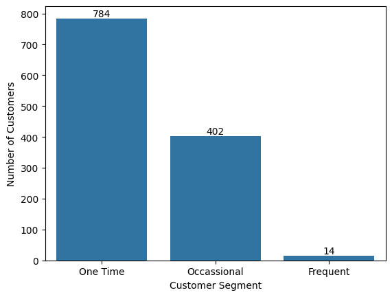

```python
# Generate a plot to see how many customers are present in each segment
plot = sns.countplot(data=orders_per_customer, x='customer_segment');
plt.xlabel('Customer Segment')
plt.ylabel('Number of Customers')

# Also show the number of customers on top of each bar
for container in plot.containers:
    plot.bar_label(container)

plt.show()
```

**Observations**:

- Orders have been placed by 1200 unique customers
- There are 784 customers who placed only 1 order
- There are 402 customers who placed orders occassionally (2-5 orders per customer)
- There are 14 customers who placed orders more frequently (6 or more orders per customer)

#### Restaurant Name

**There are 178 unique restuarants. Let's analyze what are the top 10 restuarants based on the number of orders they received**

```python
# Generate a plot to show the top 10 restuarants based on the number of orders they received

# Identify the top 10 restuarants based on the number of orders
top_10_restaurants = data['restaurant_name'].value_counts().head(10).index.tolist()

#Identify the orders for the top 10 restuarants
data_top_10_restaurants = data[data['restaurant_name'].isin(top_10_restaurants)]
```

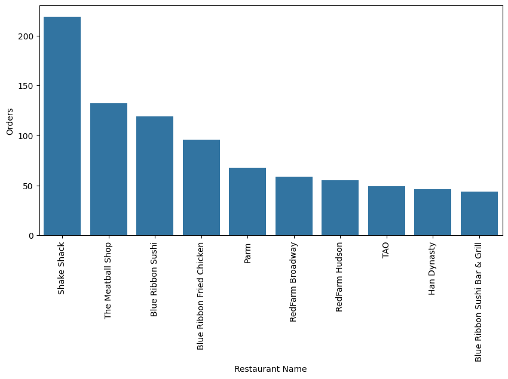

```python
# Generate a plot with the data for the top 10 restaurants, and sort the bars with the top restaurant towards left
plt.figure(figsize=(10,5))
sns.countplot(data=data_top_10_restaurants, x='restaurant_name', order=top_10_restaurants);
plt.xticks(rotation=90)
plt.xlabel('Restaurant Name')
plt.ylabel('Orders')
plt.show()
```

```python
# Check what was the lowest number of orders for a restaurant
data['restaurant_name'].value_counts().tail(10)
```

| restaurant_name | count |
| --- | --- |
| Hunan Manor | 1 |
| Coppola's East | 1 |
| Emporio | 1 |
| Wa Jeal | 1 |
| Le Zie 2000 Trattoria | 1 |
| Rye House | 1 |
| Hiroko's Place | 1 |
| Frank Restaurant | 1 |
| Sarabeth's West | 1 |
| 'wichcraft | 1 |

**dtype:** int64

Observations:

- Orders have been placed across 178 restaurants
- Shake Shack received the maximum orders with 219 orders placed
- There are many restuarants that received only 1 order

#### Cuisine Type

**There are 14 cuisine types in the order data set. Let's analyze which cuisines are popular**

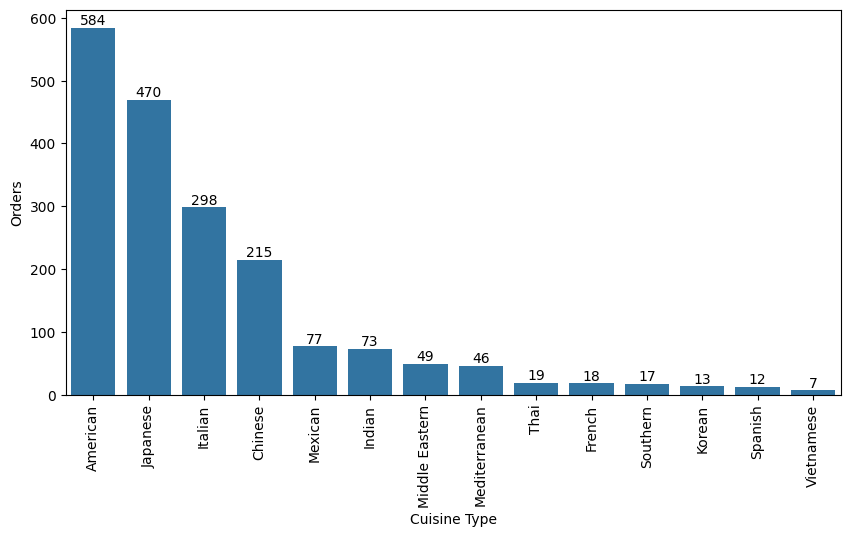

```python
# Write the code here

# Create a count plot for the cuisine types. Order the bars based on the number of orders for a cuisine type showing the most popular cuisine first
cuisine_order = data['cuisine_type'].value_counts().index

plt.figure(figsize=(10, 5))
plot = sns.countplot(data=data, x='cuisine_type', order=cuisine_order);
plt.xticks(rotation=90)
plt.xlabel('Cuisine Type')
plt.ylabel('Orders')

# Show the number of orders above each bar
for container in plot.containers:
    plot.bar_label(container)

plt.show()
```

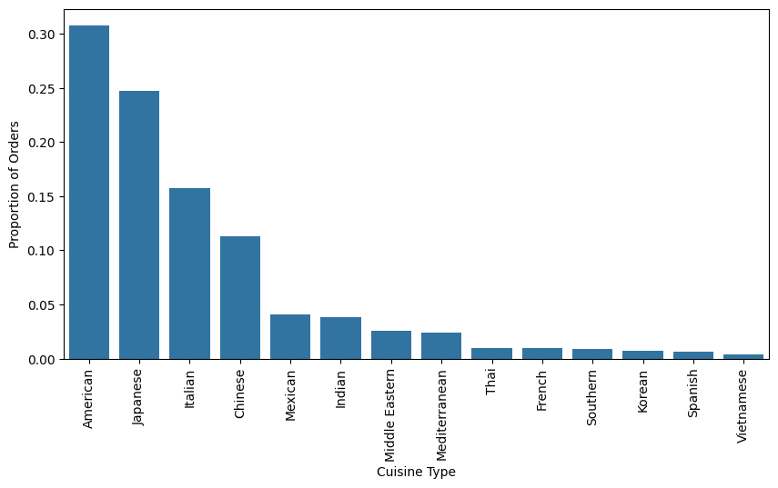

```python
# Using normalized counts, create a bar plot to represent the percentage of orders belonging to a cuisine

normalized_counts = data['cuisine_type'].value_counts(normalize=True).reset_index()
normalized_counts.columns = ['cuisine_type', 'proportion']

plt.figure(figsize=(10, 5))
sns.barplot(data=normalized_counts, x='cuisine_type', y='proportion');
plt.xticks(rotation=90)
plt.xlabel('Cuisine Type')
plt.ylabel('Proportion of Orders')
plt.show()
```

#### Cost of the order

**Let's check how does the cost of the order is distributed**

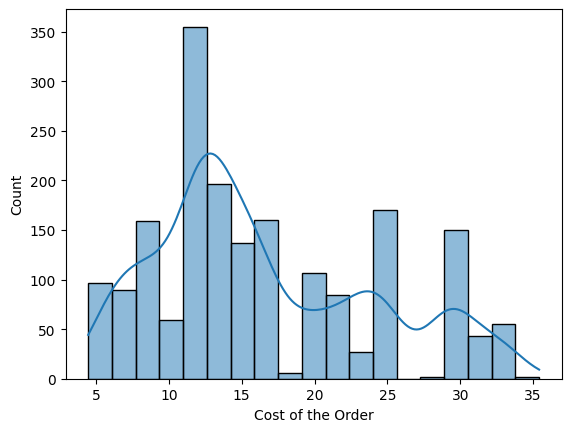

```python
# Create a histogram for the cost of the order and observe which cost range has the maximum orders
sns.histplot(data=data, x='cost_of_the_order', kde=True);
plt.xlabel('Cost of the Order');
```

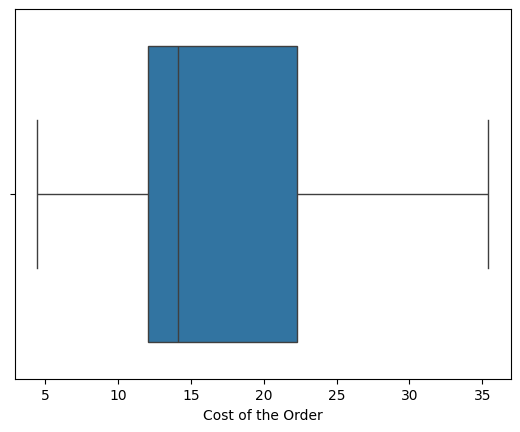

```python
# Create a box plot to see distribution of the cost of the orders
sns.boxplot(data=data, x='cost_of_the_order');
plt.xlabel('Cost of the Order');
```

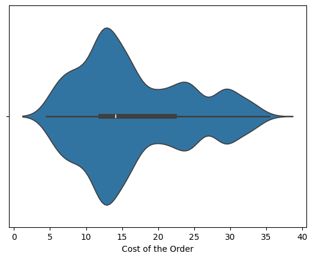

```python
# Create a violin plot to see distribution of the cost of the orders
sns.violinplot(data=data, x='cost_of_the_order');
plt.xlabel('Cost of the Order');
```

**Observations**:

- Distribution of the cost of the order is positively skewed with a lot of low cost orders
- Cost range of about 11.5-13.5 is having the maximum orders
- 50% of all the orders cost between 12.08 and 22.3
- Minimum cost of order was about 4.5
- Maximum cost of order was about 35.5

#### Day of the week

**Let's check which day of the week had the most demand**

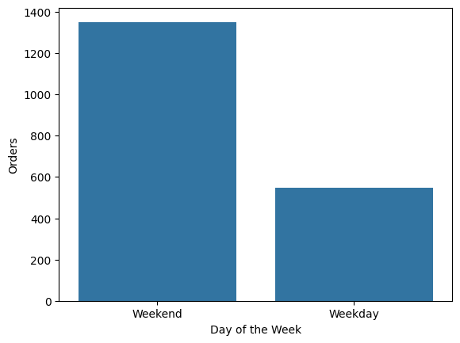

```python
# Create a count plot for the day of the week
sns.countplot(data=data, x='day_of_the_week');
plt.xlabel('Day of the Week')
plt.ylabel('Orders')
plt.show()
```

**Observations**:

- More orders were placed on Weekends compared to Weekdays, with weekends having more than double the orders on weekdays

#### Rating

**Let's check the distribution of the rating of the orders**

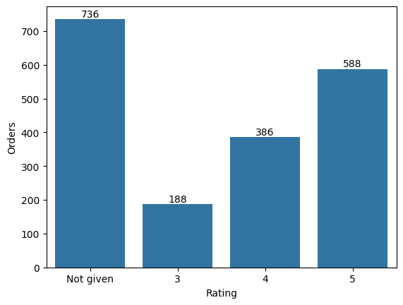

```python
# Create a count plot for the rating of the orders. Show the number of orders at the top of each bar
plot = sns.countplot(data=data, x='rating', order=['Not given', '3', '4', '5']);
plt.xlabel('Rating')
plt.ylabel('Orders')

for container in plot.containers:
    plot.bar_label(container)

plt.show()
```

```python
# Check the percentage of orders having a particular rating
data[data['rating'] != 'Not given']['rating'].value_counts(normalize=True)*100
```

| rating | proportion |
| --- | --- |
| 5 | 50.60 |
| 4 | 33.22 |
| 3 | 16.18 |

**dtype:** float64

**Observations**:

- About 39% of all the orders are not rated
- Out of the orders that are rated, about 84% of the orders are rated 4 or 5, meaning the customers are satisfied with their orders

#### Food preparation time

**Let's analyze the distribution of the preparation time for the food**

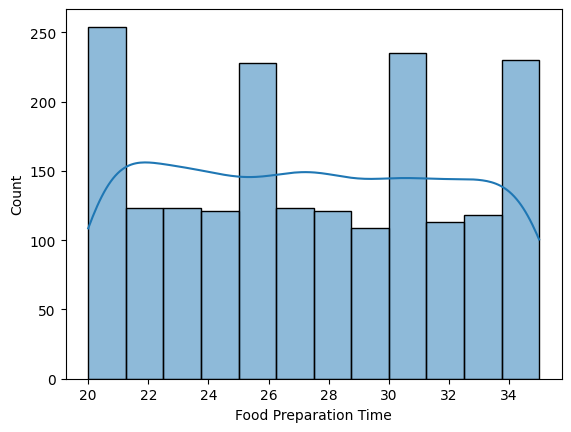

```python
# Create a histogram for the food preparation time and observe the distribution
sns.histplot(data=data, x='food_preparation_time', kde=True);
plt.xlabel('Food Preparation Time');
```

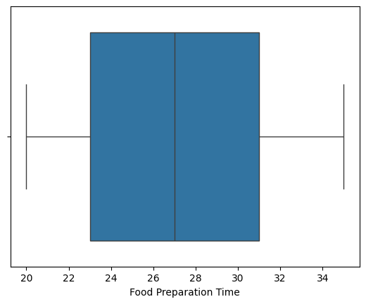

```python
# Create a box plot to observe the distribution
sns.boxplot(data=data, x='food_preparation_time');
plt.xlabel('Food Preparation Time');
```

**Observations**:

- Food preparation time is almost evenly distributed
- Average time to prepare an order is about 27 minutes, which is about the same as the median of the food preparation time

#### Delivery time

**Let's analyze the distribution of the delivery time**

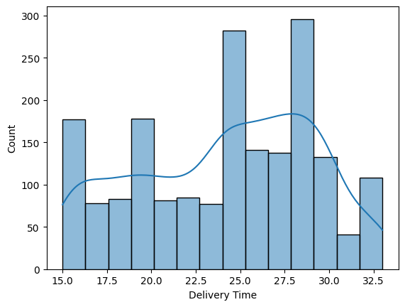

```python
sns.histplot(data=data, x='delivery_time', kde=True);
plt.xlabel('Delivery Time');
```

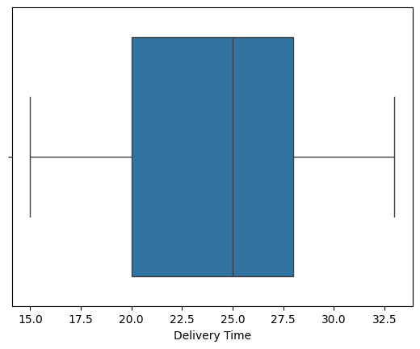

```python
sns.boxplot(data=data, x='delivery_time');
plt.xlabel('Delivery Time');
```

Observations:

- Distribution of the delivery time is negatively skewed with many orders that took more time to deliver
- Delivery time for the orders ranged between 15 to 33 mins
- 75% of the orders took more than 20 mins to be delivered

### **Question 7**: Which are the top 5 restaurants in terms of the number of orders received? [1 mark]

```python
# Write the code here
# Identify the counts of orders for each restuarant and print the top 5 restuarants
data['restaurant_name'].value_counts().head()
```

| restaurant_name | count |
| --- | --- |
| Shake Shack | 219 |
| The Meatball Shop | 132 |
| Blue Ribbon Sushi | 119 |
| Blue Ribbon Fried Chicken | 96 |
| Parm | 68 |

**dtype:** int64

#### **Observations**:

Top 5 restaurants in term of number of orders received are:

- Shake Shack with 219 orders
- The Meatball Shop with 132 orders
- Blue Ribbon Sushi with 119 orders
- Blue Ribbon Fried Chicken 96 orders
- Parm with 68 orders

### **Question 8**: Which is the most popular cuisine on weekends? [1 mark]

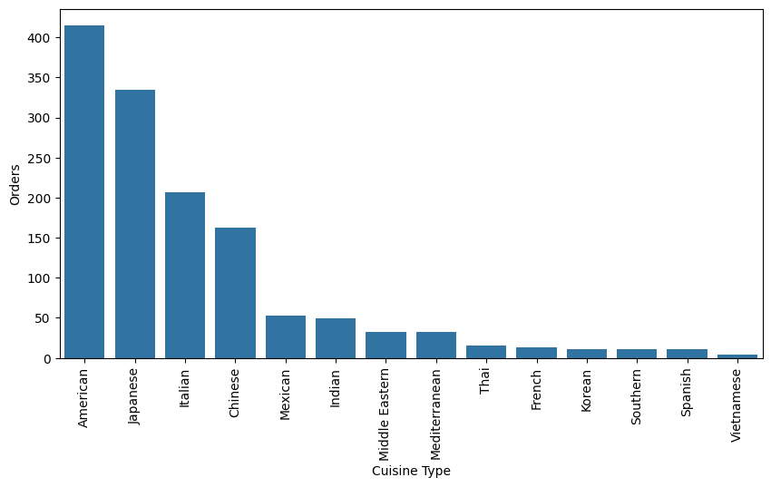

```python
# Write the code here

# Identify the orders placed on weekend
weekend_orders = data[data.day_of_the_week=='Weekend']

# Identify the number of weekend orders for each cuisine type
cuisine_order = weekend_orders['cuisine_type'].value_counts().index

# Create a plot to see the trend of orders based on cuisine type on weekend
plt.figure(figsize=(10,5))
sns.countplot(data=weekend_orders, x='cuisine_type', order=cuisine_order);
plt.xticks(rotation=90)
plt.xlabel('Cuisine Type')
plt.ylabel('Orders')
plt.show()
```

#### **Observations**:

- American cuisine is the most popular on Weekends, followed by Japanese, Italian and Chinese cuisines
- This is in line with the overall trend for the cuisine types

### **Question 9**: What percentage of the orders cost more than 20 dollars? [2 marks]

```python
# Write the code here
# Filter the orders that costed more than 20 dollar and identify the percentage based on the number of records in the filtered dataset and the original dataset
data[data.cost_of_the_order > 20].shape[0] / data.shape[0] * 100
```

```
29.24130663856691
```

#### **Observations**:

About 29% of the orders cost more than 20 dollars

### **Question 10**: What is the mean order delivery time? [1 mark]

```python
# Write the code here
# Use the mean function to caluclate the average
data.delivery_time.mean()
```

```
np.float64(24.161749209694417)
```

#### **Observations**:

Mean delivery time for an order is about 24 minutes

### **Question 11:** The company has decided to give 20% discount vouchers to the top 3 most frequent customers. Find the IDs of these customers and the number of orders they placed. [1 mark]

```python
# Write the code here

# Use value_count function to get number of orders placed by each customer.
# Check top 5 customers to see if any top customers have placed same number of orders and report all the customers with the top 3 count

data.customer_id.value_counts().head()
```

| customer_id | count |
| --- | --- |
| 52832 | 13 |
| 47440 | 10 |
| 83287 | 9 |
| 250494 | 8 |
| 259341 | 7 |

**dtype:** int64

#### **Observations**:

Top 3 frequent customers are

- 52832 with 13 orders
- 47440 with 10 orders
- 83287 with 9 orders

### **Question 12**: Perform a multivariate analysis to explore relationships between the important variables in the dataset. (It is a good idea to explore relations between numerical variables as well as relations between numerical and categorical variables) [10 marks]

```python
# Write the code here

# Create another dataset with the orders that are rated, and convert the rating variable to an integer to apply numerical functions on rating such as min, max, average, etc
data_with_ratings = data[data.rating != 'Not given'].copy()
data_with_ratings['rating'] = data_with_ratings['rating'].astype('int64')
```

#### Cost of the order Vs Day of the week

**Let's check how the cost of the order varies based on the day of the week**

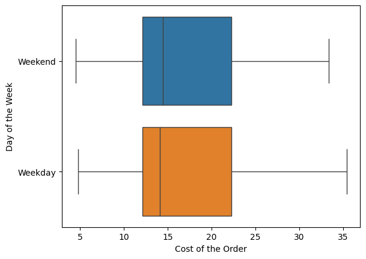

```python
# Create box plots to observe any difference in cost of the orders placed on weekdays compared to weekend
sns.boxplot(data=data, x='cost_of_the_order', y='day_of_the_week', hue='day_of_the_week');
plt.xlabel('Cost of the Order')
plt.ylabel('Day of the Week')
plt.show()
```

```python
# Check average cost of order on weekend and weekday
data.groupby('day_of_the_week')['cost_of_the_order'].mean()
```

| day_of_the_week | cost_of_the_order |
| --- | --- |
| Weekday | 16.31 |
| Weekend | 16.57 |

**dtype:** float64

**Observations**:

- Cost of the order has almost similar distribution on Weekday and Weekend. There is only a slight difference between the median value of the cost of the order
- Average cost of the orders on weekend and weekday is almost the same
- There are a few weekday orders that were a little bit more expensive than the weekend orders

#### Cost of the order Vs Cuisine type

**Cost of the order may depend on the cuisine. Let's analyze the relationship between the cost of the order and cuisine**

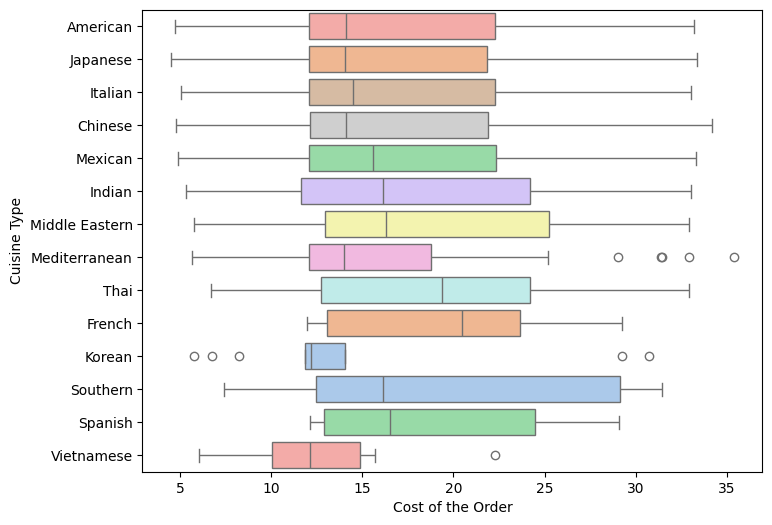

```python
# Create a boxplot to see how cost of the order varies based on the cuisine. Sort the boxplots with most popular cuisine at the top
plt.figure(figsize=(8,6))
sns.boxplot(data=data, x='cost_of_the_order', y='cuisine_type', hue = "cuisine_type", palette='pastel', order=cuisine_order);
plt.xlabel('Cost of the Order')
plt.ylabel('Cuisine Type')
plt.show()
```

**Observations**:

- Chinese cuisine has the widest range for the cost of the orders
- Mediterranean cuisine generally has orders on the cheaper side compared to other cuisines, but there are few orders that are on the expensive side
- Korean cuisine has very less orders, but has a lot of variation in the cost of those orders
- Japanese, Mexican, American and Italian cuisines have almost same range for the cost of the orders
- Vietnamese cuisine is the cheapest of all the cuisines

#### Cuisine Type Vs Day of the week

**Let's check on what day of the week a cuisine was popular**

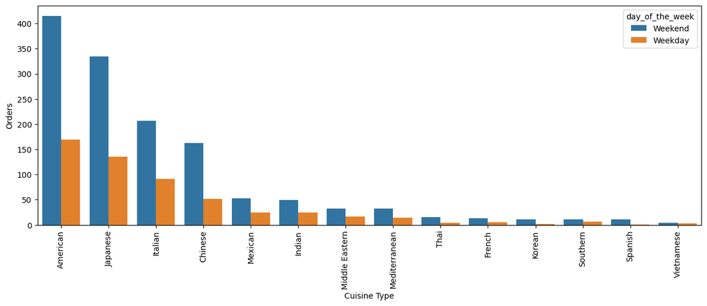

```python
# Create a count plot for cuisine type and create separate bars for each day of the week within each cuisine type category
# Also show the most popular cuisine first on the plot
plt.figure(figsize=(15,5))
sns.countplot(data=data, x='cuisine_type', hue='day_of_the_week', order=cuisine_order);
plt.xticks(rotation=90)
plt.xlabel('Cuisine Type')
plt.ylabel('Orders')
plt.show()
```

**Observations**:

All cuisines were more popular on weekends compared to weekdays

#### Cuisine Vs Rating

**Let's check which cuisine is having higher rating**

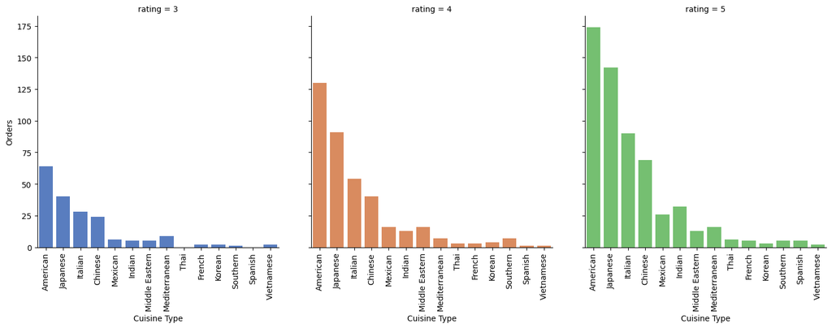

```python
# Using a separate plot for each rating type, create count plots for each cuisine to see the distribution of ratings across all cuisines
# Sort the bars with the most popular cuisine on the left
g = sns.catplot(data=data_with_ratings, x='cuisine_type', col='rating', kind='count', hue='rating', palette='muted', legend=False, order=cuisine_order)
g.set_xticklabels(rotation=90)
g.set_axis_labels('Cuisine Type', 'Orders')
plt.show()
```

**American, Chinese, Japanese and Italian cuisines combined has the maximum number of orders that are rated. Let's check the average rating each cuisine has received**

```python
# Group the rated data by cuisine_type, and calculate the count, mean and median for the rating column with the grouped data
cuisine_summary = data_with_ratings.groupby('cuisine_type')['rating'].agg(['count','mean','median']).reset_index()
cuisine_summary
```

|  | cuisine_type | count | mean | median |
| --- | --- | --- | --- | --- |
| 0 | American | 368 | 4.30 | 4.00 |
| 1 | Chinese | 133 | 4.34 | 5.00 |
| 2 | French | 10 | 4.30 | 4.50 |
| 3 | Indian | 50 | 4.54 | 5.00 |
| 4 | Italian | 172 | 4.36 | 5.00 |
| 5 | Japanese | 273 | 4.37 | 5.00 |
| 6 | Korean | 9 | 4.11 | 4.00 |
| 7 | Mediterranean | 32 | 4.22 | 4.50 |
| 8 | Mexican | 48 | 4.42 | 5.00 |
| 9 | Middle Eastern | 34 | 4.24 | 4.00 |
| 10 | Southern | 13 | 4.31 | 4.00 |
| 11 | Spanish | 6 | 4.83 | 5.00 |
| 12 | Thai | 9 | 4.67 | 5.00 |
| 13 | Vietnamese | 5 | 4.00 | 4.00 |

**Observations**:

- Spanish cuisine has the highest average rating of 4.83, but it has only 6 orders
- Vietnamese cuisine has the lowest average rating of 4, with only 5 orders
- Conisdering a minimum of 50 rated orders, the Indian cuisine has highest average rating of 4.5, followed by Japanese cuisine at 4.37, Italian cuisine at 4.36, Chinese cuisine at 4.34 and American cuisine at 4.3

#### Rating Vs Delivery time

**Rating of an order may depend on factors like preparation time of the order and delivery time of the order. Let's analyze the relationship between them**

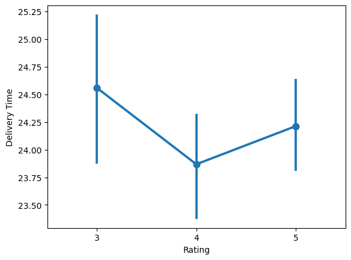

```python
# Using the data set for rated orders, draw a pointplot to see the relationship between rating and delivery time
sns.pointplot(data=data_with_ratings, x='rating', y='delivery_time');
plt.xlabel('Rating')
plt.ylabel('Delivery Time')
plt.show()
```

**Observations**:

Average delivery time for rated orders is almost similar for all the three rating scores. So the delivery time of the order doesn't seem to impact the rating by too much

#### Rating Vs Food preparation time

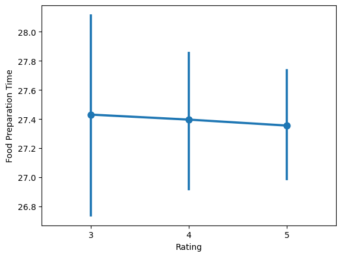

```python
# Using the data set for rated orders, draw a pointplot to see the relationship between rating and food preparation time
sns.pointplot(data=data_with_ratings, x='rating', y='food_preparation_time');
plt.xlabel('Rating')
plt.ylabel('Food Preparation Time')
plt.show()
```

**Observations**:

Average food preparation time for rated orders is almost similar for all the three rating scores. So the food preparation time of the order doesn't seem to impact the rating by too much

#### Rating Vs Cost of the order

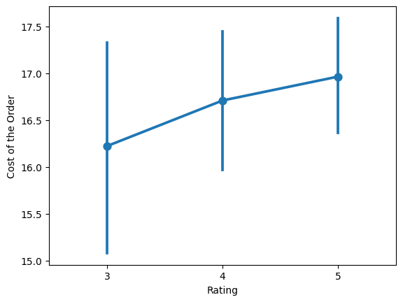

```python
# Using the data set for rated orders, draw a pointplot to see the relationship between rating and cost of the order
sns.pointplot(data=data_with_ratings, x='rating', y='cost_of_the_order');
plt.xlabel('Rating')
plt.ylabel('Cost of the Order')
plt.show()
```

**Observations**:

Average cost of the order for rated orders is almost similar for all the three rating scores. So the cost of the order doesn't seem to impact the rating by too much

#### Rating Vs Day of the week

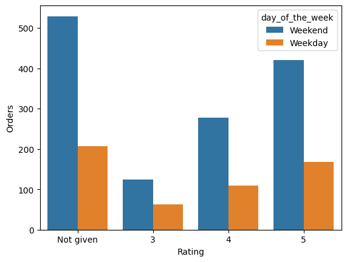

```python
sns.countplot(data=data, hue='day_of_the_week', x='rating', order=['Not given', '3', '4', '5']);
plt.xlabel('Rating')
plt.ylabel('Orders')
plt.show()
```

**Observation**:

Weekends have more orders than weekdays for all the rating categories

#### Restaurant Vs Average Rating

**Let's check which restaurants are highly rated by the customers**

```python
# Check the number of rated orders each restaurant had
orders_per_restaurant = data_with_ratings['restaurant_name'].value_counts()
orders_per_restaurant
```

| restaurant_name | count |
| --- | --- |
| Shake Shack | 133 |
| The Meatball Shop | 84 |
| Blue Ribbon Sushi | 73 |
| Blue Ribbon Fried Chicken | 64 |
| RedFarm Broadway | 41 |
| ... | ... |
| DespaÌ±a | 1 |
| Rye House | 1 |
| Frank Restaurant | 1 |
| Sarabeth's West | 1 |
| 'wichcraft | 1 |

156 rows × 1 columns

**dtype:** int64

**There are a lot of restaurants that had only 1 order. To check the highest rated restuarants, let's consider only those restaurants that have ratings available for more than 25 orders**

```python
# Generate a summary of number of orders, average rating and median rating per restaurant using the orders that are rated

restaurant_summary = data_with_ratings.groupby('restaurant_name')['rating'].agg(['count', 'mean', 'median']).reset_index()

# Filter restaurants that have more than 25 ratings, and sort by mean rating in descending order to observe the highest rated restaurants
restaurant_summary[restaurant_summary['count'] >= 25].sort_values(by='mean', ascending=False)
```

|  | restaurant_name | count | mean | median |
| --- | --- | --- | --- | --- |
| 132 | The Meatball Shop | 84 | 4.51 | 5.00 |
| 125 | TAO | 28 | 4.36 | 4.00 |
| 16 | Blue Ribbon Fried Chicken | 64 | 4.33 | 4.50 |
| 117 | Shake Shack | 133 | 4.28 | 4.00 |
| 104 | RedFarm Broadway | 41 | 4.24 | 4.00 |
| 17 | Blue Ribbon Sushi | 73 | 4.22 | 4.00 |
| 105 | RedFarm Hudson | 34 | 4.18 | 4.00 |
| 94 | Parm | 39 | 4.13 | 4.00 |

**Observations**:

With a minimum of 25 rated orders,

- The Meatball Shop is having the highest average rating of 4.51
- Parm is having the minimum average rating of 4.13
- Shake Shack is having the highest number of rated orders, but is at 4th place for the average rating

#### Restaurant Vs Cost of the order (Revenue)

**Let's check which are the top performing restaurants based on the revenue**

```python
# Calculate the number of orders, sum of cost of the orders (revenue), average cost of the order, median cost of the order, maximum cost of the order and minimum cost of the order for each restaurant
restaurant_cost_summary = data.groupby('restaurant_name')['cost_of_the_order'].agg(['count', 'sum', 'mean', 'median', 'max', 'min']).reset_index()

# As there are 180 restaurants in the data set, check the summary for the restaurants that have at least 25 orders
top_restaurants = restaurant_cost_summary[restaurant_cost_summary['count'] >= 25].sort_values(by='sum', ascending=False)
top_restaurants
```

|  | restaurant_name | count | sum | mean | median | max | min |
| --- | --- | --- | --- | --- | --- | --- | --- |
| 136 | Shake Shack | 219 | 3579.53 | 16.34 | 15.28 | 33.03 | 4.75 |
| 153 | The Meatball Shop | 132 | 2145.21 | 16.25 | 14.07 | 33.03 | 5.05 |
| 21 | Blue Ribbon Sushi | 119 | 1903.95 | 16.00 | 14.02 | 33.37 | 5.82 |
| 20 | Blue Ribbon Fried Chicken | 96 | 1662.29 | 17.32 | 14.34 | 33.18 | 5.73 |
| 109 | Parm | 68 | 1112.76 | 16.36 | 14.67 | 31.43 | 5.72 |
| 121 | RedFarm Broadway | 59 | 965.13 | 16.36 | 14.07 | 32.98 | 5.48 |
| 122 | RedFarm Hudson | 55 | 921.21 | 16.75 | 14.12 | 33.03 | 4.75 |
| 145 | TAO | 49 | 834.50 | 17.03 | 15.28 | 33.22 | 6.69 |
| 66 | Han Dynasty | 46 | 755.29 | 16.42 | 13.90 | 34.19 | 5.67 |
| 22 | Blue Ribbon Sushi Bar & Grill | 44 | 666.62 | 15.15 | 14.68 | 33.03 | 4.85 |
| 125 | Rubirosa | 37 | 660.45 | 17.85 | 15.38 | 33.03 | 5.77 |
| 143 | Sushi of Gari 46 | 37 | 640.87 | 17.32 | 14.31 | 31.43 | 5.77 |
| 103 | Nobu Next Door | 42 | 623.67 | 14.85 | 12.35 | 33.37 | 4.47 |
| 56 | Five Guys Burgers and Fries | 29 | 506.47 | 17.46 | 14.12 | 33.03 | 5.72 |
| 100 | Momoya | 30 | 492.13 | 16.40 | 14.12 | 32.93 | 6.02 |
| 23 | Blue Ribbon Sushi Izakaya | 29 | 485.09 | 16.73 | 14.07 | 33.03 | 6.79 |
| 146 | Tamarind TriBeCa | 27 | 426.71 | 15.80 | 14.02 | 29.39 | 6.07 |
| 80 | Jack's Wife Freda | 25 | 416.75 | 16.67 | 14.12 | 32.93 | 5.67 |
| 13 | Bareburger | 27 | 399.74 | 14.81 | 13.77 | 32.93 | 5.63 |

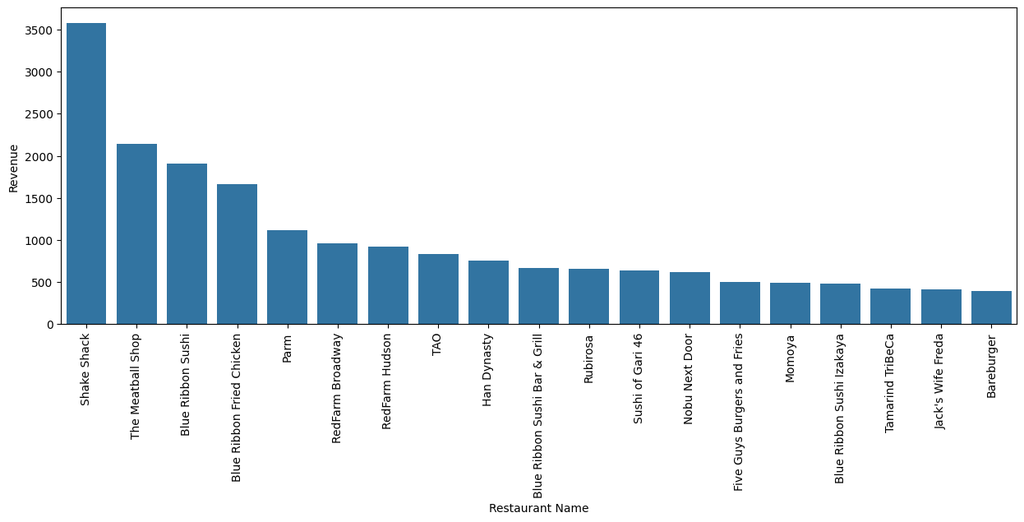

```python
# Create a barplot to observe the revenue earned by the restaurants with atleast 25 orders

plt.figure(figsize=(15,5))
sns.barplot(data=top_restaurants, x='restaurant_name', y='sum');
plt.xlabel('Restaurant Name')
plt.ylabel('Revenue')
plt.xticks(rotation=90)
plt.show()
```

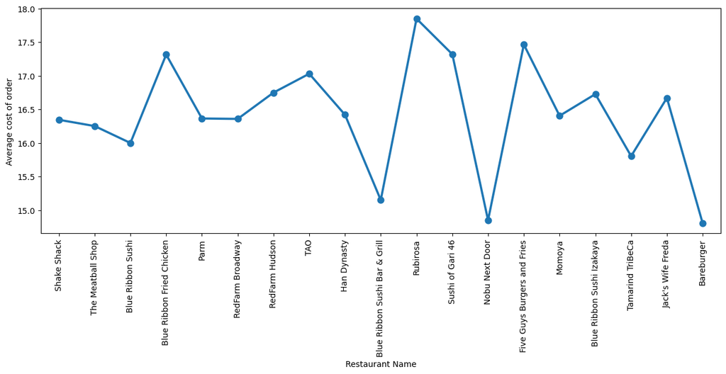

```python
# Create a pointplot to observe the average cost of order for restaurants with atleast 25 orders

plt.figure(figsize=(15,5))
sns.pointplot(data=top_restaurants, x='restaurant_name', y='mean');
plt.xlabel('Restaurant Name')
plt.ylabel('Average cost of order')
plt.xticks(rotation=90)
plt.show()
```

**Observations**:

With a minimum of 25 orders,

- Shakeshack has the highest revenue
- Bareburger has the lowest revenue
- Rubirosa is having the highest average cost per order
- Bareburger has the lowest average cost per order

#### Food preparation time Vs Cuisine

**Let's observe how is the food preparation time varying based on the cuisine**

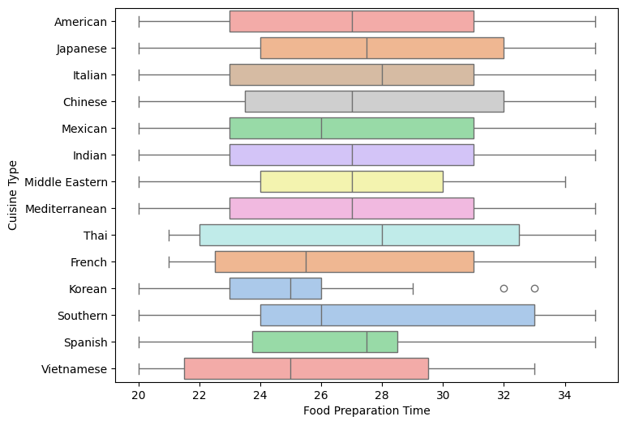

```python
# Create a boxplot to see how food preparation time varies based on the cuisine
plt.figure(figsize=(8,6))
sns.boxplot(data=data, x='food_preparation_time', y='cuisine_type', hue='cuisine_type', palette='pastel', order=cuisine_order);
plt.xlabel('Food Preparation Time')
plt.ylabel('Cuisine Type')
plt.show()
```

**Observations:**

- Korean cuisine is taking the least amount of time in general to prepare the food even though it has couple of orders that took more time to be prepared
- Japanese, Mexican, American, Indian, Italian, Mediterranean, Chinese, Southern and Spanish cuisines have almost same range of time to prepare the food

#### Delivery time Vs Cuisine

**Let's observe how is the delivery time varying based on the cuisine**

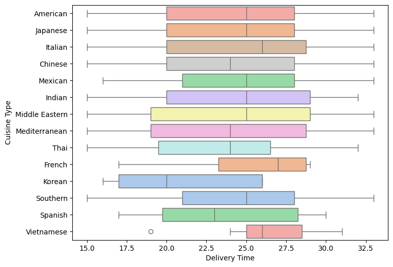

```python
# Create a boxplot to see how delivery time varies based on the cuisine
plt.figure(figsize=(8,6))
sns.boxplot(data=data, x='delivery_time', y='cuisine_type', hue='cuisine_type', palette='pastel', order=cuisine_order);
plt.xlabel('Delivery Time')
plt.ylabel('Cuisine Type')
plt.show()
```

**Observations:**

- Korean cuisine it taking the least amount of time to deliver the food in general
- American, Japanese, Italian, Chinese, Middle Eastern, Mediterranean and Southern cuisines have the same range of delivery time for their orders
- Vietnamese cuisine is generally taking longer to be delivered.

#### Food preparation time Vs Day of the week

**Let's check if food preparation time is changing based on the day of the week**

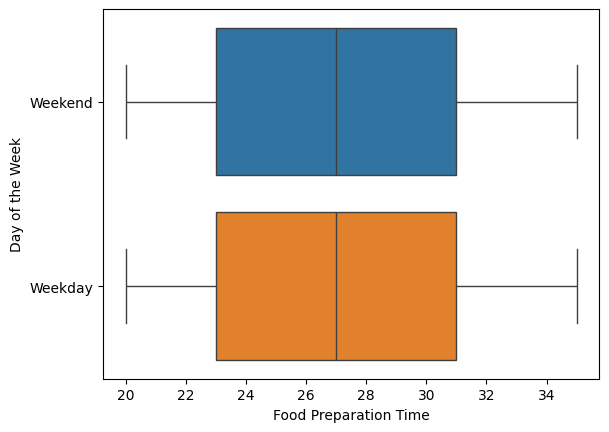

```python
# Generate a boxplot to observe food preparation time over the day of the week
sns.boxplot(data=data, x='food_preparation_time', y='day_of_the_week', hue='day_of_the_week');
plt.xlabel('Food Preparation Time')
plt.ylabel('Day of the Week')
plt.show()
```

**Observations:**

Food preparation time in general doesn't vary based on the day of the week. It has almost idential distribution for both kind of days

#### Food preparation time Vs Cuisine Type Vs Day of the week

**We observed that food preparation time in general doesn't vary based on the day of the week. Let's see if it varies based on day of the week for each cuisine**

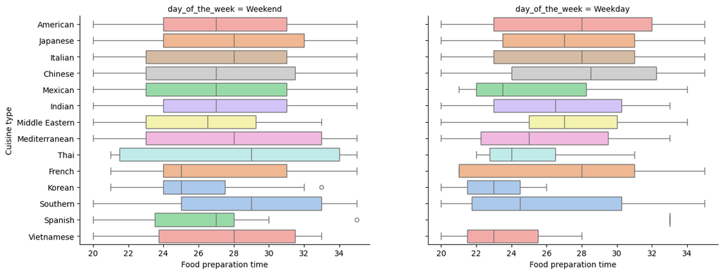

```python
# Use catplot to generate 2 separate box plots to observe distriubtion of food preparation time for each cuisine
# Order the box plots based on popularity of cuisine, with the most popular cuisine on the top
# Use aspect parameter to apply appropriate width to both the plots
# Use wspace parameter to add some gap between the 2 plots
g = sns.catplot(data=data, x='food_preparation_time', y='cuisine_type', col='day_of_the_week', legend=False, kind='box', hue='cuisine_type', aspect=1.3, order=cuisine_order, palette='pastel');
g.fig.subplots_adjust(wspace=0.2)
g.set_axis_labels('Food preparation time', 'Cuisine type')
plt.show()
```

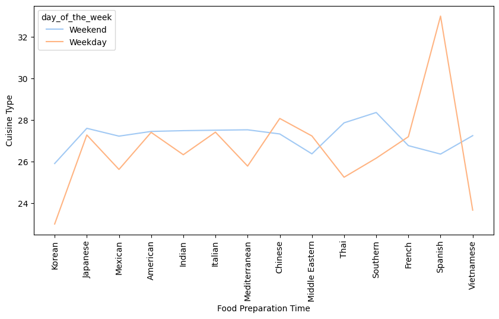

```python
# Use lineplot to show the average food preparation time for all the cuisines.
# Use day of the week as the hue to draw separate lines for type of the day
# Hide the confidence internal by using errorbar parameter
plt.figure(figsize=(10,5))
sns.lineplot(data=data, y='food_preparation_time', x='cuisine_type', hue='day_of_the_week', palette='pastel', errorbar=None);
plt.xlabel('Food Preparation Time')
plt.ylabel('Cuisine Type')
plt.xticks(rotation=90)
plt.show()
```

#### Delivery time vs Day of the week

**Let's check how does the delivery time vary based on the day of the week**

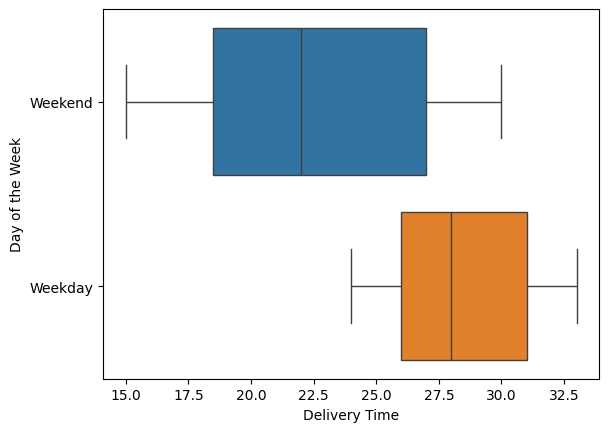

```python
# Generate a boxplot to observe delivery time over the day of the week
sns.boxplot(data=data, x='delivery_time', y='day_of_the_week', hue='day_of_the_week');
plt.xlabel('Delivery Time')
plt.ylabel('Day of the Week')
plt.show()
```

**Observations**:

- Delivery time for the food was generally higher on weekday compared to weekends

#### Delivery time Vs Cuisine Type Vs Day of the week

**Let's check if any cuisine had consistent pattern in delivery time over weekends and weekdays**

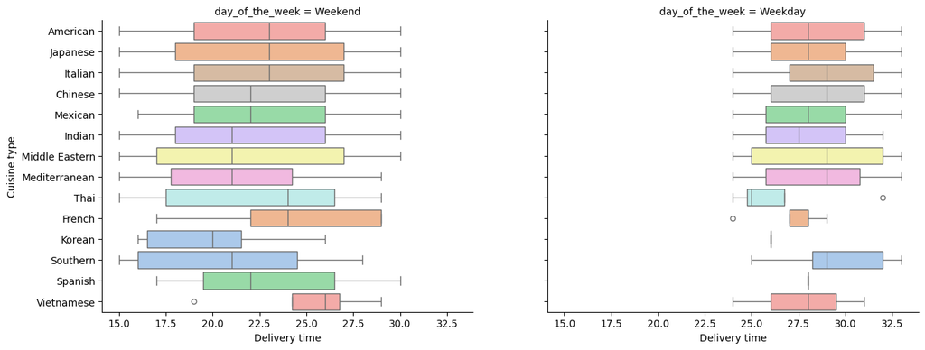

```python
# Use catplot to generate 2 separate box plots to observe distriubtion of food preparation time for each cuisine
# Use aspect parameter to apply appropriate width to both the plots
# Use wspace parameter to add some gap between the 2 plots
g = sns.catplot(data=data, x='delivery_time', y='cuisine_type', col='day_of_the_week', legend=False, kind='box', hue='cuisine_type', aspect=1.3, order=cuisine_order, palette='pastel');
g.fig.subplots_adjust(wspace=0.2)
g.set_axis_labels('Delivery time', 'Cuisine type')
plt.show()
```

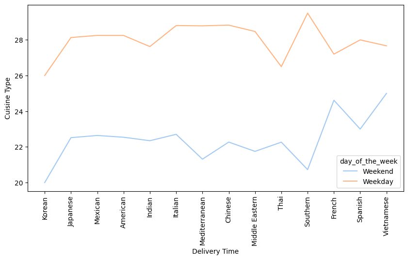

```python
# Use lineplot to show the average food preparation time for all the cuisines.
# Use day of the week as the hue to draw separate lines for type of the day
# Hide the confidence internal by using errorbar parameter
plt.figure(figsize=(10,5))
sns.lineplot(data=data, y='delivery_time', x='cuisine_type', hue='day_of_the_week', palette='pastel', errorbar=None);
plt.xlabel('Delivery Time')
plt.ylabel('Cuisine Type')
plt.xticks(rotation=90)
plt.show()
```

**Observations**:

- All cuisines had many orders on weekends that were delivery quickly compared to orders delivered on weekdays
- All cuisines had higher average delivery time on weekdays compared to weekends

#### Restuarants Vs Customers

**Let's check which restaurants received orders from most number of customers and the least number of customers**

```python
# Group the orders by restaurant name, and find out the count of unique customer id for each restaurant
# Sort the values in descending order
data.groupby(['restaurant_name'])['customer_id'].nunique().reset_index().sort_values(by='customer_id', ascending=False)
```

|  | restaurant_name | customer_id |
| --- | --- | --- |
| 136 | Shake Shack | 170 |
| 153 | The Meatball Shop | 102 |
| 21 | Blue Ribbon Sushi | 75 |
| 20 | Blue Ribbon Fried Chicken | 68 |
| 109 | Parm | 56 |
| ... | ... | ... |
| 147 | Tarallucci e Vino Restaurant | 1 |
| 169 | Xe May Sandwich Shop | 1 |
| 168 | Woorijip | 1 |
| 167 | Wo Hop Restaurant | 1 |
| 164 | Wa Jeal | 1 |

178 rows × 2 columns

**Observations**:

- Shake Shack prepared orders for the 170 customers which is the highest number of customers
- There are many restaurants that prepared order for just 1 customer

#### Cuisine type Vs Customers

**Let's see how many customers ordered each type of cuisine**

```python
# Group the orders by cuisine type, and find out the count of unique customer id for each cuisine
# Sort the values in descending order
data.groupby(['cuisine_type'])['customer_id'].nunique().reset_index().sort_values(by='customer_id', ascending=False)
```

|  | cuisine_type | customer_id |
| --- | --- | --- |
| 0 | American | 417 |
| 5 | Japanese | 304 |
| 4 | Italian | 233 |
| 1 | Chinese | 162 |
| 8 | Mexican | 63 |
| 3 | Indian | 54 |
| 9 | Middle Eastern | 37 |
| 7 | Mediterranean | 37 |
| 12 | Thai | 15 |
| 2 | French | 13 |
| 10 | Southern | 12 |
| 6 | Korean | 11 |
| 11 | Spanish | 8 |
| 13 | Vietnamese | 5 |

**Observations**:

- American cusine got the orders from 417 customers, which is the highest
- Vietnamese cuisine got the orders from only 5 customer, which is the lowest

#### Restaurant Vs Cuisine

**As we have observed that Vietnamese, Spanish, Southern, Korean, French, Thai, Middle Eastern and Mediterranean cuisines are having very less number of orders, let's see how many restuarants serve a particular cuisine**

```python
# Group the data by cuisine type, and find out how many restaurant names appear for each cuisine
data.groupby(['cuisine_type'])['restaurant_name'].nunique().sort_values(ascending=False)
```

| cuisine_type | restaurant_name |
| --- | --- |
| American | 41 |
| Italian | 31 |
| Japanese | 29 |
| Chinese | 16 |
| Indian | 14 |
| Mexican | 11 |
| Thai | 9 |
| Middle Eastern | 7 |
| Korean | 5 |
| Mediterranean | 5 |
| French | 3 |
| Spanish | 3 |
| Vietnamese | 3 |
| Southern | 2 |

**dtype:** int64

**Observations:**

- American cuisine is being offered by 41 restaurants
- Vietnamese, Spanish, Southern, Korean, French, Thai, Middle Eastern and Mediterranean cuisines are being offered by less than 10 restaurants

#### Heatmap

**Let's generate a heatmap to see the correlation between the numeric variables**

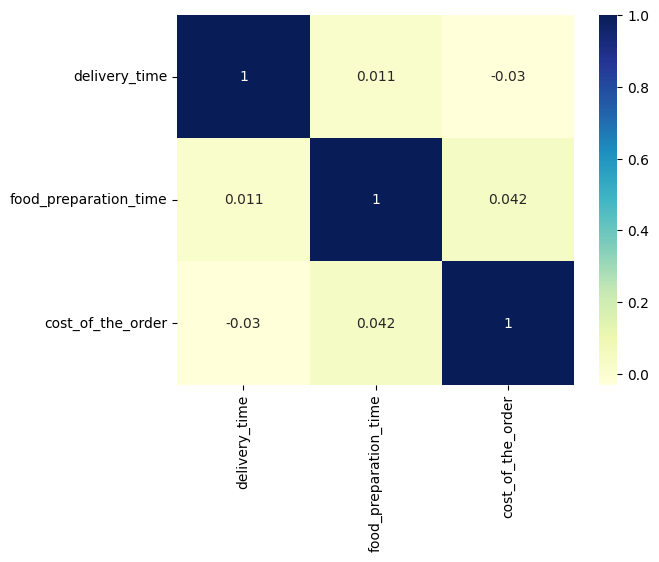

```python
sns.heatmap(data[['delivery_time', 'food_preparation_time', 'cost_of_the_order']].corr(), annot=True, cmap='YlGnBu');
```

**Observations**: There correlationship between all the variables is almost close to 0, meaning the value of these variable don't depend on each other

### **Question 13:** The company wants to provide a promotional offer in the advertisement of the restaurants. The condition to get the offer is that the restaurants must have a rating count of more than 50 and the average rating should be greater than 4. Find the restaurants fulfilling the criteria to get the promotional offer. [3 marks]

```python
# Write the code here
# Summary for rated orders for each restaurant has been already calculated and has been stored in restaurant_summary Data Frame during multivariate analysis for "Restaurant Vs Average Rating"
# Use restaurant_summary Data Frame to filter restaurants with more than 50 orders and mean rating of more than 4
restaurant_summary[(restaurant_summary['count']>50) & (restaurant_summary['mean']>4)]
```

|  | restaurant_name | count | mean | median |
| --- | --- | --- | --- | --- |
| 16 | Blue Ribbon Fried Chicken | 64 | 4.33 | 4.50 |
| 17 | Blue Ribbon Sushi | 73 | 4.22 | 4.00 |
| 117 | Shake Shack | 133 | 4.28 | 4.00 |
| 132 | The Meatball Shop | 84 | 4.51 | 5.00 |

#### **Observations**:

Restaurants fulfilling the criteria of rating count of more than 50 and average rating greater than 4 are:

- Blue Ribbon Fried Chicken
- Blue Ribbon Sushi
- Shake Shack
- The Meatball Shop

### **Question 14:** The company charges the restaurant 25% on the orders having cost greater than 20 dollars and 15% on the orders having cost greater than 5 dollars. Find the net revenue generated by the company across all orders. [3 marks]

```python
# Write the code here
# Add a new column 'order_revenue' to the data frame, and assign a calculated value to column variable based on the cost of the order
data['order_revenue'] = data['cost_of_the_order'].apply(lambda x: x*0.25 if x > 20 else (x*0.15 if x > 5 else 0))

# Calculate the sum of the order_revenue column to find the net revenue generated by the company across all the orders
data['order_revenue'].sum()
```

```
np.float64(6166.303)
```

```python
# Check for how many orders did the company charge 25%
data[data['cost_of_the_order'] > 20].shape[0]
```

```
555
```

```python
# Check for how many orders did the company charge 15%
data[(data['cost_of_the_order']> 5) & (data['cost_of_the_order'] <= 20)].shape[0]
```

```
1334
```

```python
# Check how many orders did not generate any revenue for the company
data[data['cost_of_the_order'] <= 5].shape[0]
```

```
9
```

#### **Observations:**

- Net revenue for the company across all orders is about 6166.3
- Company charged 25% commission on 555 orders
- Company charged 15% commission on 1334 orders
- Company did not generate any revenue on 9 orders

### **Question 15:** The company wants to analyze the total time required to deliver the food. What percentage of orders take more than 60 minutes to get delivered from the time the order is placed? (The food has to be prepared and then delivered.) [2 marks]

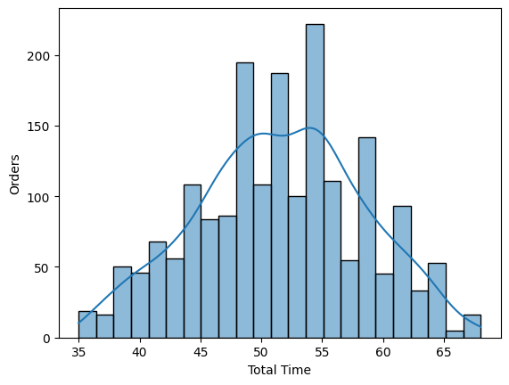

```python
# Write the code here
# Calculate the total time taken to deliver the order from the time the order is placed, and save it in the 'total_time' column in the data frame
data['total_time'] = data['food_preparation_time'] + data['delivery_time']

# Generate a histogram to view the distribution of total time taken
sns.histplot(data=data, x='total_time', kde=True);
plt.xlabel('Total Time');
plt.ylabel('Orders');
```

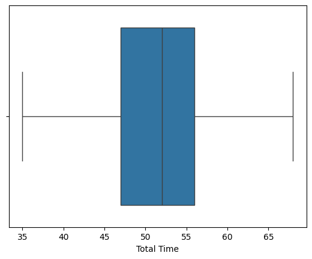

```python
# Generate a boxplot to view the distribution of total time taken
sns.boxplot(data=data, x='total_time');
plt.xlabel('Total Time');
```

```python
# Using total_time column, calculate % of orders that took more than 60 mins to get delivered
data[data.total_time > 60].shape[0] / data.shape[0] * 100
```

```
10.537407797681771
```

#### **Observations**:

- About 10.5% of all the orders took more than 60 mins to deliver the food after the order was placed
- Distribution of total time is slightly negatively skewed

### **Question 16:** The company wants to analyze the delivery time of the orders on weekdays and weekends. How does the mean delivery time vary during weekdays and weekends? [2 marks]

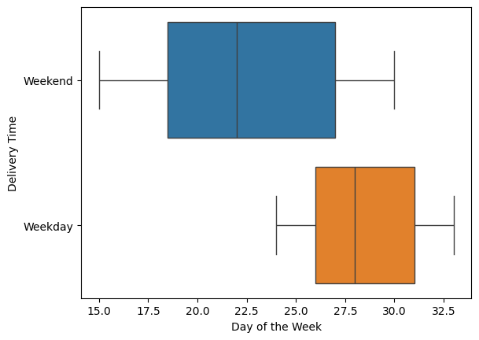

```python
# Write the code here
# Generate a box plot to observe the deliveryf time based on day of the week
sns.boxplot(data=data, x='delivery_time', y='day_of_the_week', hue='day_of_the_week');
plt.xlabel('Day of the Week');
plt.ylabel('Delivery Time');
```

```python
# Use the mean function to identify the mean delivery time after grouping the data by day of the week
data.groupby('day_of_the_week')['delivery_time'].mean()
```

| day_of_the_week | delivery_time |
| --- | --- |
| Weekday | 28.34 |
| Weekend | 22.47 |

**dtype:** float64

#### **Observations**:

- Mean delivery time of the orders was considerably less on weekend compared to weekday, with orders getting delivered about 6 mins faster on weekends
- Mean delivery time on weekend was 22.47 minutes
- Mean delivery time on weekday was 28.34 minutes
- 50% of the weekday orders took 28 or more minutes to be delivered
- More than 75% weekend orders were delivered within 28 mins

### Conclusion and Recommendations

### **Question 17:** What are your conclusions from the analysis? What recommendations would you like to share to help improve the business? (You can use cuisine type and feedback ratings to drive your business recommendations.) [6 marks]

### Conclusions:

Dataset extracted by the aggregator company has 1898 orders that were placed by 1200 customers to order food from 178 restaurants serving 14 unique cuisines. The dataset has been analyzed to understand the trends on restaurants, cuisines, ratings, food preparation and delivery time, and the cost of the order. Below insights have been gathered with the help of descriptive analysis and various visualizations:

#### Insights on orders

- 784 customers placed only 1 order
- Only 14 customers placed 6 or more orders
- Weekend had more than double the orders on weekday
- All cuisines had more orders on weekend compared to weekday

#### Insights on restaurants

- Shake Shack is the most popular restuarant with 219 orders and prepared orders 170 customers which is the highest.
- The Meatball Shop and Blue Ribbon Sushi were also popular.
- There are many restuarants that received just 1 order.

#### Insights on cuisine

- American cuisine is the most popular cuisine with 584 orders.
- Popularity of cuisines is similar of weekend and weekday
- American, Japanese, Italian and Chinese cuisines combined received about 82% of all the orders.
- Vietnamese cuisine was the least popular cuisine with just 7 orders

#### Insights on rating

- 736 orders have not been rated, which is about 39% of all the orders
- 84% of the rated orders received rating of 4 or 5 implying that customers were satisfied with their orders
- Considering a minimum of 50 rated orders, the Indian cuisine had the highest average rating of 4.5, followed by Japanese cuisine with average rating of 4.37
- Considering a minimum of 25 rated orders, The Meatball Shop had the highest average rating of 4.51, followed by TAO with average rating of 4.36
- Rating of orders doesn't seem to depend on the food preparation time or delivery time of the order

#### Insights on delivery time and food preparation time

- Average time to prepare food was about 27 minutes
- 50% of the orders took upto 27 minutes to be prepared
- Delivery time for the orders ranged between 15 to 33 minutes, with 75% of the orders taking more than 20 minutes to deliver
- Average time to deliver an order was about 24 minutes
- Cost range and average cost of the orders was similar on weekend and weekday
- Majority of the cuisines had a similar cost range
- Majority of cuisines had a similar range of food preparation time and delivery time
- Korean cuisine took the least amount of time to prepare the orders
- Food preparation time was almost similar on both weekday and weekend
- Delivery time was higher on weekday compared to weekend

### Recommendations:

- Since there is a very high percentage of orders that are not rated, company should encourage customers to rate the orders to get their feedback for further improvement
- Weekdays has less than 50% of orders compared to weekends. Company can think about giving some promotions to get more orders on weekdays
- Company should focus on improving the delivery time on weekday
- As there are many customers who placed just one order, company should look forward to give some promotions to attract back those customers
- There are many restaurants that had just 1 order. Company should evaluate if they want spend resources to keep supporting those restaurants on the platform
- Indian, Mediterranean, Mexican and Middle Eastern cuisines have good ratings but less orders compared to other popular cuisines. Company should evaluate if they can onboard more restaurants that serve these cuisines
- Vietnamese, Spanish, Southern, Korean, French and Thai cuisines are being served by very few restaurants. Company should evaluate if they want to onboard more popular restaurants on the platform that offer these cuisines
- As the food preparation time and delivery time doesn't seem to impact the rating, and the dataset doesn't have review comments, company can ask customers to leave review comments along with the rating. This will help the company understand what drives the rating for the orders